# 11_QuantLing_Section

Eric Wilbanks

4/17/2020 - 4/20/2020

## 1. Goals for Section

1. FSA review and exercises
2. FST review and exercises

## 2. Any other Questions?

## 3. Finite State Automata (FSA)

### 3.1 FSA Basics

**Finite State Automata (FSAs)**

FSAs are mathematical machines/models of computation that **transition from one state to another in response to an input**.

FSAs are characterized by:

1. finite set of states ($Q$)
2. set of transition values/symbol set ($\Sigma$)
3. start state
4. final state(s)
5. transition function/matrix ($\delta(q,i)$)

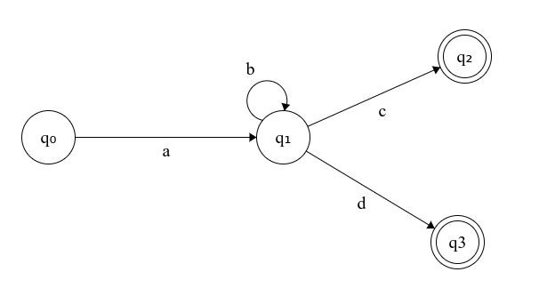

Example FSA #1

```
For the above FSA, what are the parameters we outlined as features of FSAs? ($Q$, $\Sigma$, etc.)
```

```
# Q: {q0, q1, q2, q3}
# Sigma: {a, b, c, d}
# start: q0
# end: {q2, q3}
# transition matrix
delta <- matrix(rbind(c('q1','-','-','-'),c('-','q1','q2','q3'),c('-','-','-','-'),c('-','-','-','-')), nrow = 4, dimnames = list(c("q0","q1","q2","q3"),c("a","b","c","d")))
print(delta)
```

```
##    a    b    c    d
## q0 "q1" "-"  "-"  "-"
## q1 "-"  "q1" "q2" "q3"
## q2 "-"  "-"  "-"  "-"
## q3 "-"  "-"  "-"  "-"
```

FSAs can be either **deterministic** or **non-deterministic**:

- *deterministic*: has a unique transition for all state-symbol combinations (no decision point $\rightarrow$ deterministic)
- *non-deterministic*: any non-unique transitions for any state-character combination

```
1) Is FSA #1 deterministic or non-deterministic?
2) What is one edit we could make to change it to the other option?
```

```
##############
# 1) FSA is deterministic: each state only has one unique path for any symbol from that state;
# 2) We could add another path with a repeated symbol out of a state; for example, adding a transition from q1 to q2 that is "b"; then there would be two possible choices for "b" when you're in q1, and it's not 100% determined by the state-symbol you're in.
##############
```

### 3.2 Acceptor FSAs

One core application of FSAs is matching input strings to some pattern (like regular expressions). If an FSA can take an input, process its sub-parts, and then successfully reach a final state, the input is **accepted**. Otherwise, it is rejected.

```
1) What types of strings can FSA #1 match/accept?
2) What would a corresponding regular expression be?
3) Is it deterministic or non-deterministic?
```

```
##############
# 1) FSA 1 could match any strings that start with a, have 0 or more b's, and then end with either c or d.
# 2) /ab*(c|d)/
##############
```

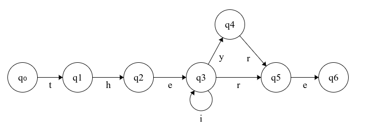

Example FSA #2

```
1) What types of strings can FSA #2 match/accept?
2) What would a corresponding regular expression be?
3) Is it deterministic or non-deterministic?
4) How can we edit this FSA to only accept English words?
5) Would the resulting FSA be deterministic or non-deterministic?
```

```
##############
# 1) there, theyre, theire, theiyre, theiire, theiiire, ....
# 2) /thei*y?re/
# 3) Deterministic; all state/symbol transitions are unique
# 4) Remove the q3-q3 'i' loop, instead, have a new state which bypasses the top paths (see image below)
# 5) still deterministic
##############
```

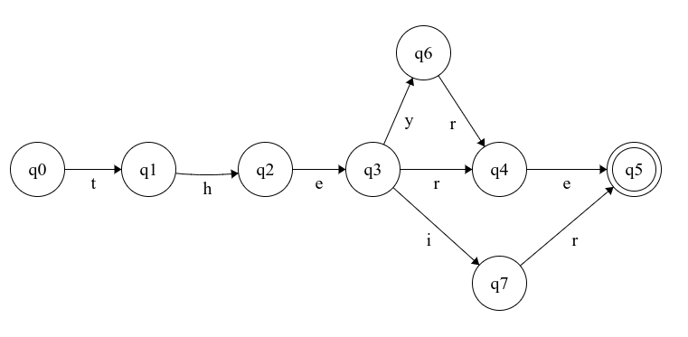

Updated FSA #2

## 4. Finite State Transducers (FST)

Instead of moving through symbols in an input and checking to see if an FSA can accept the input, what if we could move through symbols in an input **and** build up an ouput based off of this?

Consider the following Finite State Transducer (FST):

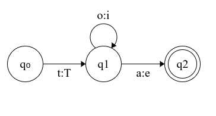

Example FST#1

### input = “ta”

| current state | input symbol | output |
| --- | --- | --- |
| q0 | t | T |
| q1 | a | Te |
| q2 |  | Te |

### input = “tooa”

| current state | input symbol | output |
| --- | --- | --- |
| q0 | t | T |
| q1 | o | Ti |
| q1 | o | Tii |
| q1 | a | Tiie |
| q2 |  | Tiie |

### input = “Toa”

?

```
#This would crash; there's no path from q0 that an input 'T' can take; only possible path is if input starts with 't'
```

### input = “tta”

?

```
#This would also crash; we can move from q0 to q1 with the first 't', but there's no path from q1 if the input is 't'.
```